# analysis_tfh

### This is for analysis of Tfh cells from Kim. et al. data (Nat Comm 2020) under collaboration with Can.

#### 1. Read in Data (Lung cells only)

```r
setwd('~/scratch60/kim')
```

```r
library(dplyr)
library(stringr)
library(data.table)
```

```r
annot <- read.table('GSE131907_Lung_Cancer_cell_annotation.txt', sep="\t", header=T)
dim(annot)
head(annot)
sum(annot$Sample_Origin %in% c("mLN","nLung","tLung"))
annot$number <- annot$Index %>% as.character %>% strsplit(split="_") %>% sapply("[",3)
```

wc -l GSE131907_Lung_Cancer_raw_UMI_matrix.txt

head -1 GSE131907_Lung_Cancer_raw_UMI_matrix.txt > header_count.txt

awk -F' ' '{print NF; exit}' header_count.txt

```r
umi_header <- readLines('header_count.txt')
samples <- strsplit(umi_header, split="\t")[[1]]
meta_umi <- data.frame(raw=samples[-1],
                       barcode = samples[-1] %>% strsplit(split="_") %>% sapply("[",1),
                       source = samples[-1] %>% strsplit(split="_") %>% sapply("[",2),
                       index = samples[-1] %>% strsplit(split="_") %>% sapply("[",3))
```

nLung(Nxx) + tLung(Txx) = LUNG = 88144

mBrain = NS = 29060

nLN = LN = 37446

PE = EFFUSION = 20304

tL/B + mLN21479 = BRONCHO + EBUS = 33552

```r
# mat <- readLines('GSE131907_Lung_Cancer_raw_UMI_matrix.txt')
# dat <- strsplit(mat, split="\t") %>% unlist %>% matrix(nrow=nrow(mat))
```

```r
mat <- fread('GSE131907_Lung_Cancer_raw_UMI_matrix.txt')
dim(mat)
```

```r
sel0 <- meta_umi$source == "LUNG"
meta_lu <- meta_umi[sel0,]
annot_lu <- annot[annot$Sample_Origin %in% c("nLung","tLung"),]
lungcell <- c('Index',as.character(meta_lu$raw))
mat_lu <- mat[, ..lungcell]
```

```r
dim(meta_lu)
dim(mat_lu)
dim(annot_lu)
```

```r
annot_lu <- annot_lu[match(meta_lu$raw, annot_lu$Index),]
```

```r
# save(mat, annot, meta_umi, file = "kim_umi.RData")
save(mat_lu, meta_lu, annot_lu, file="kim_umi_lu.RData")
rm(umi_header, samples)
```

#### 2. Clustering and look for Tfh cell group

```r
load('kim_umi_lu.RData')
rm(meta_lu)

class(mat_lu) <- class(as.data.frame(mat_lu))
genes <- mat_lu$Index
mat_lu <- mat_lu[,-1]

annot_lu$index_new <- NA
for (num in levels(factor(annot_lu$number))){
    id <- which(annot_lu$number==num)
    annot_lu$index_new[id] <- paste0(num, "_", 1:length(id))
}

# sum(is.na(annot_lu$index_new))
# table(annot_lu$index_new) %>% max

names(mat_lu) <- annot_lu$index_new
save(annot_lu, genes, mat_lu, file="kim_umi_lu.RData")
```

```r
gsum <- rowSums(mat_lu)
gene0 <- gsum<1e-3 * ncol(mat_lu)
mat_lu1 <- mat_lu[!gene0,]
dim(mat_lu1)

cmln <- colSums(mat_lu1)/10e6 ##counts in million
mat_lu2 <- t(mat_lu1)/cmln
```

```r
library(ggplot2)
library(dplyr)
library(Seurat)
```

```r
rm(list=ls())
load('kim_umi_lu.RData')

rownames(mat_lu) <- genes
kp <- CreateSeuratObject(counts = mat_lu, project = "KimDataset", min.cells = 3, min.features = 200)
summary(kp)
```

```
Length  Class   Mode
     1 Seurat     S4
```

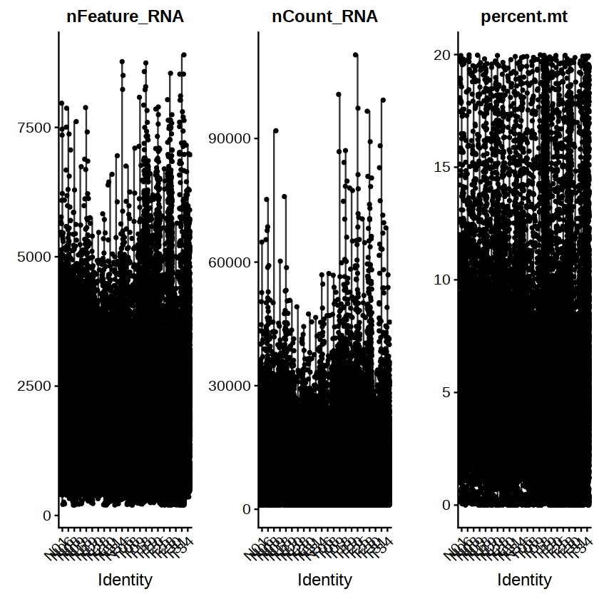

```r
kp[["percent.mt"]] <- PercentageFeatureSet(kp, pattern = "^MT-")

VlnPlot(kp, features = c("nFeature_RNA", "nCount_RNA", "percent.mt"), ncol = 3)

plot1 <- FeatureScatter(kp, feature1 = "nCount_RNA", feature2 = "percent.mt")
plot2 <- FeatureScatter(kp, feature1 = "nCount_RNA", feature2 = "nFeature_RNA")
CombinePlots(plots = list(plot1, plot2))
# kp <- subset(kp, subset = nCount_RNA < 15000 & nFeature_RNA < 5000 & percent.mt < 10)
```

```r
## normalization
kp <- NormalizeData(kp, normalization.method = "LogNormalize", scale.factor = 10000)
kp <- FindVariableFeatures(kp, selection.method = "vst", nfeatures = 2000)
top10 <- head(VariableFeatures(kp), 10)
plot1 <- VariableFeaturePlot(kp)
plot2 <- LabelPoints(plot = plot1, points = top10, repel = TRUE, xnudge = 0, ynudge = 0)
# CombinePlots(plots = list(plot1, plot2))
```

```
PC_ 1
Positive:  ELF3, CLDN4, MUC1, WFDC2, KRT18, TACSTD2, EPCAM, KRT8, AGR3, SMIM22
	   GPRC5A, SLC34A2, KRT19, FXYD3, MAL2, MGST1, CYR61, CLDN3, SOX4, SLPI
	   CXCL17, SFTA2, AGR2, S100A14, EMP2, MALL, KRT7, SFTA3, TMEM98, AK1
Negative:  ALOX5AP, RGS1, FCER1G, HLA-DPB1, NKG7, CCL4, LTB, HLA-DQA1, HLA-DPA1, KLRB1
	   LYZ, GZMB, CD68, C1QA, SNX10, GPR183, C1QB, C1QC, MARCO, HLA-DRA
	   APOC1, HLA-DRB1, VSIG4, HLA-DQB1, MSR1, MCEMP1, MRC1, HLA-DMB, MNDA, CCL3
PC_ 2
Positive:  ELF3, AGR3, CLDN4, SMIM22, MUC1, SLC34A2, FXYD3, EPCAM, WFDC2, AGR2
	   KRT8, TACSTD2, KRT18, CXCL17, CLDN3, KRT19, SFTA2, MAL2, SFTA3, SFTPB
	   NAPSA, CRNDE, S100A14, TSPAN1, PIGR, RAB25, TMC5, SLC44A4, DHCR24, CDH1
Negative:  DCN, COL1A2, FBLN1, LUM, C1S, MMP2, MFAP4, AEBP1, COL6A2, PLAC9
	   SPARCL1, C1R, ADH1B, PCOLCE, CALD1, MGP, BGN, COL6A1, C7, COL3A1
	   RARRES2, PRELP, SFRP2, CCDC80, COL6A3, SPARC, FBLN2, THY1, NBL1, DPT
PC_ 3
Positive:  NKG7, KLRB1, LTB, GZMB, C12orf75, BIRC3, HOPX, GNLY, IGKC, FGFBP2
	   CD27, OCIAD2, RGS1, DUSP4, FKBP11, GZMK, IGLC2, SPON2, TRDC, ITM2C
	   XCL2, CLIC3, IGHA1, CD79A, IFNG, IGHG3, PIM2, CCR7, IGLC3, TNFRSF18
Negative:  CD68, FTL, C1QA, GRN, C1QB, C1QC, APOC1, MARCO, MSR1, LYZ
	   ACP5, ALDH2, FBP1, VSIG4, CTSZ, MRC1, CTSB, MCEMP1, TREM1, CTSD
	   PSAP, GPNMB, FCER1G, SERPINA1, CSTA, LGALS3, GLUL, MS4A4A, CYP27A1, S100A9
PC_ 4
Positive:  NAPSA, SFTA2, SFTPB, S100A14, MALL, SFTPA1, SFTPD, SFTPA2, SLC22A31, SLC34A2
	   SFTA3, C4BPA, MUC1, SDC1, CXCL17, RNASE1, C8orf4, SFTA1P, PRSS8, C16orf89
	   PPP1R1B, ITGB6, CEACAM6, LRRK2, SFN, PDZK1IP1, MAL2, PEBP4, NKX2-1, KCNJ15
Negative:  C9orf24, C20orf85, C1orf194, FAM183A, RSPH1, C11orf88, MS4A8, C5orf49, SNTN, CAPS
	   CAPSL, LRRIQ1, C9orf116, DYNLRB2, MORN5, CCDC78, ZMYND10, PIFO, DNAAF1, FAM92B
	   ROPN1L, CFAP126, C11orf97, FAM216B, TEKT1, RSPH9, LDLRAD1, EFCAB1, C2orf40, CFAP53
PC_ 5
Positive:  C3, C16orf89, FBLN1, SOD3, C1S, DCN, COL1A2, SFTPD, LUM, SFTPA1
	   SFRP2, ADH1B, CCDC80, SFTPA2, C1R, PCOLCE, SFTPB, IGFBP6, SERPINF1, PEBP4
	   PGC, DPT, MFAP4, LAMP3, C4BPA, NAPSA, LRRK2, PODN, ISLR, ABCA3
Negative:  CLDN5, CLEC14A, RAMP2, VWF, EGFL7, RAMP3, ECSCR, PTPRB, CALCRL, PCAT19
	   CDH5, LDB2, ARHGAP29, GNG11, ESAM, EMCN, TSPAN7, CTNNAL1, PCDH17, ROBO4
	   NRN1, EPAS1, PLVAP, CAV1, ADGRL4, HYAL2, CD93, MMRN2, IL33, CYYR1
```

```
PC_ 1
Positive:  ELF3, CLDN4, MUC1, WFDC2, KRT18
Negative:  ALOX5AP, RGS1, FCER1G, HLA-DPB1, NKG7
PC_ 2
Positive:  ELF3, AGR3, CLDN4, SMIM22, MUC1
Negative:  DCN, COL1A2, FBLN1, LUM, C1S
PC_ 3
Positive:  NKG7, KLRB1, LTB, GZMB, C12orf75
Negative:  CD68, FTL, C1QA, GRN, C1QB
PC_ 4
Positive:  NAPSA, SFTA2, SFTPB, S100A14, MALL
Negative:  C9orf24, C20orf85, C1orf194, FAM183A, RSPH1
PC_ 5
Positive:  C3, C16orf89, FBLN1, SOD3, C1S
Negative:  CLDN5, CLEC14A, RAMP2, VWF, EGFL7
```

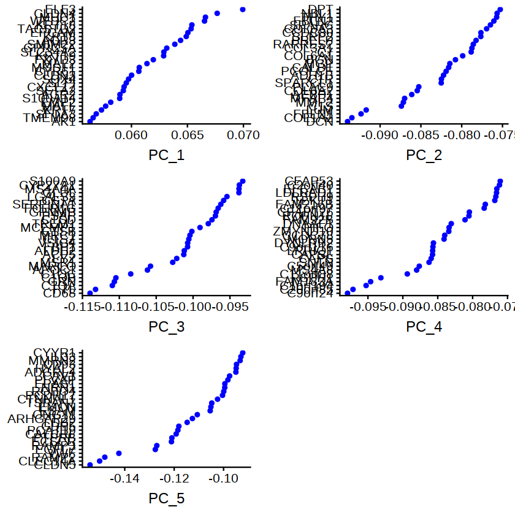

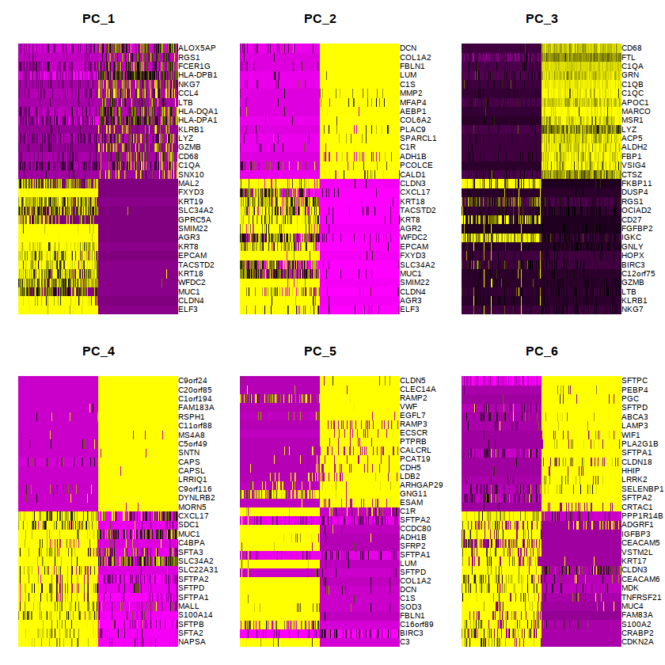

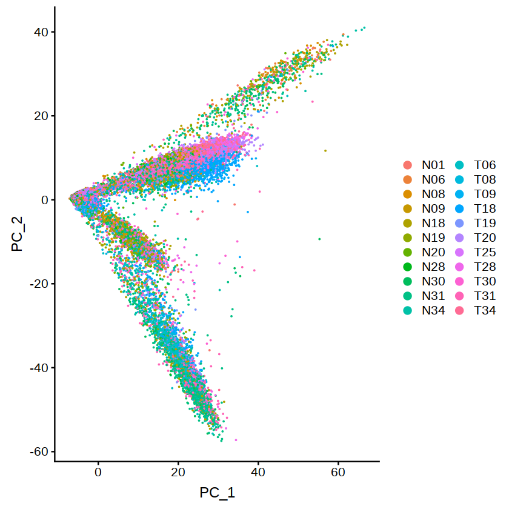

```r
## dimension reduction
all.genes <- rownames(kp)
kp <- ScaleData(kp, features = all.genes)
kp <- RunPCA(kp, features = VariableFeatures(kp))
print(kp[["pca"]], dims = 1:5, nfeatures = 5)
VizDimLoadings(kp, dims = 1:5, reduction = "pca")
DimHeatmap(kp, dims = 1:6, cells = 500, balanced = TRUE)
DimPlot(kp, reduction="pca")
```

```r
# ## determine dimensionality
# kp <- JackStraw(kp, num.replicate = 100)
# kp <- ScoreJackStraw(kp, dims = 1:20)
# JackStrawPlot(kp, dims = 1:20)
# ElbowPlot(kp)
```

```r
## clustering cells
kp <- FindNeighbors(kp, dims = 1:20)
kp <- FindClusters(kp, resolution = 0.5)
# head(Idents(kp), 5)
table(Idents(kp))
```

```
Modularity Optimizer version 1.3.0 by Ludo Waltman and Nees Jan van Eck

Number of nodes: 88144
Number of edges: 2850653

Running Louvain algorithm...
Maximum modularity in 10 random starts: 0.9462
Number of communities: 24
Elapsed time: 40 seconds
```

```
    0     1     2     3     4     5     6     7     8     9    10    11    12
18641 11430 10636  7266  7157  4085  3402  3340  2894  2621  2547  2461  2040
   13    14    15    16    17    18    19    20    21    22    23
 1867  1629  1128  1059   828   826   803   713   430   262    79
```

```r
## UMPA
kp <- RunUMAP(kp, dims = 1:20)
DimPlot(kp, reduction = "umap")
```

[output not shown]

```r
pdf('clustering_umap1_kim.pdf')
DimPlot(kp, reduction = "umap")#, plot.title="Clutering of nLung/tLung cells, original clusters")
dev.off()
```

**png:** 2

```r
## plot by markers
# kp.markers <- FindAllMarkers(kp, only.pos = TRUE, min.pct = 0.25, logfc.threshold = 0.25)
# top20 <- kp.markers %>% group_by(cluster) %>% top_n(n = 20, wt = avg_logFC)
# write.csv(top20, file="top_genes_perou.csv", row.names=F)
# top50 <- kp.markers %>% group_by(cluster) %>% top_n(n = 50, wt = avg_logFC)
# saveRDS(kp.markers, file = "Luc14_markers_f3.rds")
# DoHeatmap(kp, features = top20$gene) + NoLegend()
```

```r
# 1) Is there Tfh cluster? If so, heatmap showing signature genes of TFH. Especially IL21
sig_tfh <- c("ASCL2", "BCL6", "CD4", "CD200", "CXCR5", "IL4", "IL21", "IL6ST", "MAF", "PDCD1", "SH2D1A", "TOX2")
# 2) Is there GC B cluster? If so, heatmap showing signature genes of GCB signature,
sig_gcb <- c("AICDA", "BATF", "BACH2", "BCL6", "CD79A", "CD79B", "CD86", "DOCK8", "IRF4", "IRF8", "MYC")
```

```r
new_id <- Idents(kp)
annot_lu$cluster <- new_id
```

```r
pdf('marker_kim_gcb1.pdf', width=20, height=10)
# DimPlot(kp, reduction = "umap")
VlnPlot(kp, features = sig_gcb)
FeaturePlot(kp, features = sig_gcb)
dev.off()
pdf('marker_kim_tfh1.pdf', width=20, height=10)
# DimPlot(kp, reduction = "umap")
VlnPlot(kp, features = sig_tfh)
FeaturePlot(kp, features = sig_tfh)
dev.off()
```

**png:** 2

**png:** 2

```r
Idents(kp) <- annot_lu$number
pdf('marker_kim_gcb.pdf', width=20, height=10)
# DimPlot(kp, reduction = "umap")
VlnPlot(kp, features = sig_gcb)
FeaturePlot(kp, features = sig_gcb)
dev.off()
pdf('marker_kim_tfh.pdf', width=20, height=10)
# DimPlot(kp, reduction = "umap")
VlnPlot(kp, features = sig_tfh)
FeaturePlot(kp, features = sig_tfh)
dev.off()
```

**png:** 2

**png:** 2

```r
save(kp, file="kim_umi_lu_seurat.RData")
```

```r
table(annot_lu$Cell_type)
table(annot_lu$Cell_type.refined)
table(annot_lu$Cell_subtype)
```

```
    B lymphocytes Endothelial cells  Epithelial cells       Fibroblasts
             5946              1996             10973              3388
       MAST cells     Myeloid cells          NK cells  Oligodendrocytes
             2888             25466              7828                 0
    T lymphocytes      Undetermined
            29659                 0
```

```
    B lymphocytes Endothelial cells  Epithelial cells       Fibroblasts
             5946              1922             10973              3239
       MAST cells     Myeloid cells        T/NK cells
             2888             25466             25354
```

```
        Activated DCs          Alveolar Mac                   AT1
                  220                 13535                   530
                  AT2            CD141+ DCs       CD163+CD14+ DCs
                 2020                   196                   803
            CD1c+ DCs       CD207+CD1a+ LCs               CD4+ Th
                 1408                    93                  6673
            CD8 low T    CD8+/CD4+ Mixed Th              Ciliated
                 1465                  2471                   654
                 Club   COL13A1+ matrix FBs   COL14A1+ matrix FBs
                  439                   962                  1468
     Cytotoxic CD8+ T                  EPCs      Exhausted CD8+ T
                 2459                    74                  1939
        Exhausted Tfh         FB-like cells    Follicular B cells
                  397                     1                  3912
 GC B cells in the DZ  GC B cells in the LZ GrB-secreting B cells
                   71                    92                   186
        Lymphatic ECs       Malignant cells          MALT B cells
                  280                     0                  1202
                 MAST     Mesothelial cells         Microglia/Mac
                 2888                    34                     0
               mo-Mac             Monocytes        Myofibroblasts
                 5486                  2958                   260
         Naive CD4+ T          Naive CD8+ T                    NK
                 2023                   264                  5491
                 pDCs             Pericytes          Plasma cells
                  118                    73                   337
          Pleural Mac   Smooth muscle cells        Stalk-like ECs
                   96                   208                   425
         Tip-like ECs                  Treg                   tS1
                  822                  1804                  3270
                  tS2                   tS3             Tumor ECs
                 3018                    64                   321
         Undetermined
                 1360
```

```r
table(annot_lu[c('Cell_subtype','cluster')]) %>% write.csv(file="celltype_cluster_assignment.csv")
```

#### 3. Clustering of T/NK cells from LUNG + LN

```r
library(ggplot2)
library(dplyr)
library(Seurat)
library(stringr)
library(data.table)
```

```r
system('head -1 GSE131907_Lung_Cancer_raw_UMI_matrix.txt > header_count.txt')
umi_header <- readLines('header_count.txt')
samples <- strsplit(umi_header, split="\t")[[1]]
meta_umi <- data.frame(raw=samples[-1],
                       barcode = samples[-1] %>% strsplit(split="_") %>% sapply("[",1),
                       source = samples[-1] %>% strsplit(split="_") %>% sapply("[",2),
                       index = samples[-1] %>% strsplit(split="_") %>% sapply("[",3))

mat <- fread('GSE131907_Lung_Cancer_raw_UMI_matrix.txt')
dim(mat)

annot <- read.table('GSE131907_Lung_Cancer_cell_annotation.txt', sep="\t", header=T)
dim(annot)
head(annot)
sum(annot$Sample_Origin %in% c("mLN","nLN","nLung","tLung"))
annot$number <- annot$Index %>% as.character %>% strsplit(split="_") %>% sapply("[",3)
annot <- annot[match(meta_umi$raw, annot$Index),]

# sum(annot$Index == meta_umi$raw)
# sum(meta_umi$raw == names(mat)[-1])
```

```r
sel0 <- intersect(which(annot$Sample_Origin %in% c("nLung","tLung","mLN","nLN")), which(annot$Cell_type.refined == "T/NK cells"))
annot_ll <- annot[sel0,]
# sum(annot$Sample_Origin  %in% c("nLung","tLung","mLN","nLN") & annot$Cell_type.refined == "T/NK cells", na.rm=T)

class(mat) <- class(as.data.frame(mat))
mat_ll <- mat[,1+sel0]
# sum(names(mat_ll) == annot_ll$Index)

genes <- mat$Index
```

```r
annot_ll$index_new <- NA
for (num in levels(factor(annot_ll$number))){
    id <- which(annot_ll$number==num)
    annot_ll$index_new[id] <- paste0(num, "_", 1:length(id))
}

names(mat_ll) <- annot_ll$index_new
save(annot_ll, genes, mat_ll, file="kim_umi_ll.RData")
```

#### 4. Clustering of Lung/LN T/NK cells with Seurat

```r
rm(list=ls())
load('kim_umi_ll.RData')
# rm(annot, cel0, id, lungcell, mat, meta_umi, num, samples, sel0, umi_header)
```

```r
rownames(mat_ll) <- genes
kp <- CreateSeuratObject(counts = mat_ll, project = "KimDataset", min.cells = 3, min.features = 200)
summary(kp)

kp[["percent.mt"]] <- PercentageFeatureSet(kp, pattern = "^MT-")

VlnPlot(kp, features = c("nFeature_RNA", "nCount_RNA", "percent.mt"), ncol = 3, pt.size=0)

plot1 <- FeatureScatter(kp, feature1 = "nCount_RNA", feature2 = "percent.mt")
plot2 <- FeatureScatter(kp, feature1 = "nCount_RNA", feature2 = "nFeature_RNA")
# CombinePlots(plots = list(plot1, plot2))
# kp <- subset(kp, subset = nCount_RNA < 15000 & nFeature_RNA < 5000 & percent.mt < 10)

## normalization
kp <- NormalizeData(kp, normalization.method = "LogNormalize", scale.factor = 10000)
# kp <- NormalizeData(kp, normalization.method = "RC", scale.factor = 1e6) ## for heatmap of relative expression
kp <- FindVariableFeatures(kp, selection.method = "vst", nfeatures = 2000)
top10 <- head(VariableFeatures(kp), 10)
plot1 <- VariableFeaturePlot(kp)
plot2 <- LabelPoints(plot = plot1, points = top10, repel = TRUE, xnudge = 0, ynudge = 0)
# CombinePlots(plots = list(plot1, plot2))

## dimension reduction
all.genes <- rownames(kp)
kp <- ScaleData(kp, features = all.genes)
kp <- RunPCA(kp, features = VariableFeatures(kp))
print(kp[["pca"]], dims = 1:5, nfeatures = 5)
VizDimLoadings(kp, dims = 1:5, reduction = "pca")
DimHeatmap(kp, dims = 1:6, cells = 500, balanced = TRUE)
DimPlot(kp, reduction="pca")

## clustering cells
kp <- FindNeighbors(kp, dims = 1:20)
kp <- FindClusters(kp, resolution = 0.5)
# head(Idents(kp), 5)
table(Idents(kp))

## UMPA
# kp <- RunUMAP(kp, dims = 1:15)
DimPlot(kp, reduction = "umap")
# kp <- RunTSNE(kp, dims = 1:20)
# DimPlot(kp, reduction = "tsne")
```

[output not shown]

```
Length  Class   Mode
     1 Seurat     S4
```

```r
rm(list=ls())
load('kim_umi_ll_seurat.RData')
```

```r
pdf('umap_kim_ll.pdf', width=7, height=6)
DimPlot(kp, reduction = "umap")#, plot.title="Clutering of nLung/tLung cells, original clusters")
dev.off()
```

**png:** 2

```r
save(kp, file="kim_umi_ll_seurat.RData")
```

##### 4.1 resume

```r
load('kim_umi_ll_seurat.RData')
load('kim_umi_ll.RData')
rm(mat_ll)
annot_ll$cluster <- Idents(kp)
```

```r
markers.t <- c("CD3D", "CD3E", "CD3G")
markers.tfh <- "IL21, IL4, CXCL13, CXCR5, TOX, TOX2, BCL6, PDCD1, ICOS, CD200, MAF, ASCL2, SH2D1A, SLAMF6, BTLA, GNG4, POU2AF1, IL6ST" %>% strsplit(split=", ") %>% unlist
markers.th17 <- "IL17A, IL17F, RORA, RORC, STAT3, NR4A2" %>% strsplit(split=", ") %>% unlist
markers.th1 <- "IFNG, IL2, TBX21, STAT4, IL12RB2, BHLHE40, CXCR3" %>% strsplit(split=", ") %>% unlist
markers.th2 <- "IL4, IL5, IL13, GATA3" %>% strsplit(split=", ") %>% unlist
markers.treg <- "IL2RA, FOXP3, IKZF2, TNFRSF4, TNFRSF18" %>% strsplit(split=", ") %>% unlist

markers.nk <- "KLRC1, KLRD1, KLRF1" %>% strsplit(split=", ") %>% unlist #NKG2A=KLRC1
markers.naive <- "LEF1, TCF7, SELL, CCR7, CD8A, CD8B" %>% strsplit(split=", ") %>% unlist #TCF1=TCF7
markers.ctoxic <- "GZMA, GZMB, GZMK, PRF1, GNLY, IFNG, IL2, KLRG1, ZEB2, CX3CR1" %>% strsplit(split=", ") %>% unlist
markers.inhr <- "LAG3, TIGIT, PDCD1, HAVCR2, CTLA4" %>% strsplit(split=", ") %>% unlist
```

```r
pdf('tsne_kim_ll.pdf')
DimPlot(kp, reduction = "tsne")#, plot.title="Clutering of nLung/tLung cells, original clusters")
dev.off()
```

**png:** 2

```r
pdf('marker_kim_ll_tnk.pdf', width=20, height=12)
markers.tnk <- c(markers.t, markers.nk)
DimPlot(kp, reduction = "umap")
VlnPlot(kp, features = markers.tnk, pt.size=0)
FeaturePlot(kp, features = markers.tnk)
dev.off()
```

**png:** 2

```r
pdf('marker_kim_ll_tcd4.pdf', width=20, height=12)
VlnPlot(kp, features = markers.tfh, pt.size=0)
VlnPlot(kp, features = markers.th17, pt.size=0)
VlnPlot(kp, features = markers.th1, pt.size=0)
VlnPlot(kp, features = markers.th2, pt.size=0)
VlnPlot(kp, features = markers.treg, pt.size=0)
dev.off()
```

**png:** 2

```r
pdf('marker_kim_ll_nk.pdf', width=20, height=12)
VlnPlot(kp, features = markers.naive, pt.size=0)
VlnPlot(kp, features = markers.ctoxic, pt.size=0)
VlnPlot(kp, features = markers.inhr, pt.size=0)
dev.off()
```

**png:** 2

```r
##calculate differential expression
kp.markers <- FindAllMarkers(kp, only.pos = TRUE, min.pct = 0.25, logfc.threshold = 0.25)
top30 <- kp.markers %>% group_by(cluster) %>% top_n(n = 30, wt = avg_logFC)
```

```r
top30[top30$cluster==11,]
```

| p_val | avg_logFC | pct.1 | pct.2 | p_val_adj | cluster | gene |
| --- | --- | --- | --- | --- | --- | --- |
| 0.000000e+00 | 1.9153627 | 0.923 | 0.322 | 0.000000e+00 | 11 | ISG15 |
| 0.000000e+00 | 1.8892691 | 0.849 | 0.186 | 0.000000e+00 | 11 | IFI6 |
| 0.000000e+00 | 1.7295160 | 0.758 | 0.054 | 0.000000e+00 | 11 | IFI44L |
| 0.000000e+00 | 1.5458498 | 0.587 | 0.023 | 0.000000e+00 | 11 | IFIT3 |
| 0.000000e+00 | 1.4951348 | 0.714 | 0.096 | 0.000000e+00 | 11 | MX1 |
| 0.000000e+00 | 1.3666722 | 0.540 | 0.014 | 0.000000e+00 | 11 | IFIT1 |
| 0.000000e+00 | 1.0885912 | 0.507 | 0.042 | 0.000000e+00 | 11 | OAS1 |
| 0.000000e+00 | 1.0427096 | 0.622 | 0.156 | 0.000000e+00 | 11 | STAT1 |
| 0.000000e+00 | 0.9888099 | 0.381 | 0.012 | 0.000000e+00 | 11 | RSAD2 |
| 0.000000e+00 | 0.9886448 | 0.528 | 0.083 | 0.000000e+00 | 11 | XAF1 |
| 0.000000e+00 | 0.9507068 | 0.486 | 0.064 | 0.000000e+00 | 11 | IFI44 |
| 0.000000e+00 | 0.9228087 | 0.535 | 0.127 | 0.000000e+00 | 11 | EPSTI1 |
| 0.000000e+00 | 0.9113121 | 0.517 | 0.095 | 0.000000e+00 | 11 | EIF2AK2 |
| 0.000000e+00 | 0.8775627 | 0.287 | 0.019 | 0.000000e+00 | 11 | IFIT2 |
| 0.000000e+00 | 0.8717873 | 0.450 | 0.071 | 0.000000e+00 | 11 | MX2 |
| 0.000000e+00 | 0.8568357 | 0.457 | 0.089 | 0.000000e+00 | 11 | SAMD9L |
| 0.000000e+00 | 0.8519800 | 0.490 | 0.098 | 0.000000e+00 | 11 | IRF7 |
| 0.000000e+00 | 0.8330749 | 0.359 | 0.023 | 0.000000e+00 | 11 | USP18 |
| 0.000000e+00 | 0.7988637 | 0.322 | 0.014 | 0.000000e+00 | 11 | CMPK2 |
| 0.000000e+00 | 0.7514013 | 0.315 | 0.029 | 0.000000e+00 | 11 | OAS3 |
| 0.000000e+00 | 0.7436773 | 0.345 | 0.058 | 0.000000e+00 | 11 | PLSCR1 |
| 0.000000e+00 | 0.6861756 | 0.286 | 0.024 | 0.000000e+00 | 11 | HERC5 |
| 4.349748e-287 | 1.0374426 | 0.897 | 0.500 | 9.103152e-283 | 11 | LY6E |
| 5.350020e-242 | 0.8164482 | 0.454 | 0.119 | 1.119652e-237 | 11 | NT5C3A |
| 6.774815e-217 | 1.0017861 | 0.846 | 0.470 | 1.417833e-212 | 11 | ISG20 |
| 1.993081e-191 | 0.7114187 | 0.398 | 0.109 | 4.171121e-187 | 11 | IFI35 |
| 1.171417e-180 | 0.7882228 | 0.660 | 0.287 | 2.451542e-176 | 11 | BST2 |
| 1.023483e-157 | 0.7107071 | 0.655 | 0.296 | 2.141946e-153 | 11 | IFI16 |
| 2.000661e-152 | 0.7628474 | 0.356 | 0.105 | 4.186983e-148 | 11 | TNFSF10 |
| 1.870647e-146 | 0.6933760 | 0.559 | 0.233 | 3.914891e-142 | 11 | UBE2L6 |

CD8: 2,4,6,9,12

NK: 3,13

```r
write.csv(top30, file="top30.csv")
```

#### 5. Heatmap

```r
library(ggplot2)
library(dplyr)
library(Seurat)
library(stringr)
library(data.table)
```

```r
rm(list=ls())
load('kim_umi_ll_seurat.RData')
clusters <- Idents(kp)

## Instead, construct Seurat object with NormalizeData(method="RC")
load('kim_umi_ll.RData')
rownames(mat_ll) <- genes
kp <- CreateSeuratObject(counts = mat_ll, project = "KimDataset", min.cells = 3, min.features = 200)
kp <- NormalizeData(kp, normalization.method = "RC", scale.factor = 1e6) ## for heatmap of relative expression
Idents(kp) <- clusters

save(kp, file="kim_umi_ll_seurat_rc.RData")
```

```r
markers.tfh <- "IL21, IL4, CXCL13, CXCR5, TOX, TOX2, BCL6, PDCD1, ICOS, CD200, MAF, ASCL2, SH2D1A, SLAMF6, BTLA" %>% strsplit(split=", ") %>% unlist
markers.th17 <- "IL17A, IL17F, RORA, RORC, STAT3, NR4A2" %>% strsplit(split=", ") %>% unlist
markers.th1 <- "IFNG, IL2, TBX21, STAT4, IL12RB2, BHLHE40, CXCR3" %>% strsplit(split=", ") %>% unlist
markers.th2 <- "IL4, IL5, IL13, GATA3" %>% strsplit(split=", ") %>% unlist
markers.treg <- "IL2RA, FOXP3, IKZF2, TNFRSF4, TNFRSF18" %>% strsplit(split=", ") %>% unlist
markers.t <- "CD3D, CD3E, CD3G, CD8A, CD8B, CD4" %>% strsplit(split=", ") %>% unlist
markers.nk <- "KLRC1, KLRD1, KLRF1" %>% strsplit(split=", ") %>% unlist #NKG2A=KLRC1
markers.naive <- "LEF1, TCF7, SELL, CCR7" %>% strsplit(split=", ") %>% unlist #TCF1=TCF7
markers.ctoxic <- "GZMA, GZMB, GZMK, PRF1, GNLY, IFNG, IL2, KLRG1, ZEB2, CX3CR1" %>% strsplit(split=", ") %>% unlist
markers.inhr <- "LAG3, TIGIT, PDCD1, HAVCR2, CTLA4" %>% strsplit(split=", ") %>% unlist
markers.all <- c(markers.tfh, markers.th17, markers.th1, markers.th2, markers.treg, markers.t, markers.nk, markers.naive, markers.ctoxic, markers.inhr) %>% unique
table(markers.all) ##IFNG, PDCD1, IL4, IL2
```

```
markers.all
   ASCL2     BCL6  BHLHE40     BTLA     CCR7    CD200     CD3D     CD3E
       1        1        1        1        1        1        1        1
    CD3G      CD4     CD8A     CD8B    CTLA4   CX3CR1   CXCL13    CXCR3
       1        1        1        1        1        1        1        1
   CXCR5    FOXP3    GATA3     GNLY     GZMA     GZMB     GZMK   HAVCR2
       1        1        1        1        1        1        1        1
    ICOS     IFNG    IKZF2  IL12RB2     IL13    IL17A    IL17F      IL2
       1        1        1        1        1        1        1        1
    IL21    IL2RA      IL4      IL5    KLRC1    KLRD1    KLRF1    KLRG1
       1        1        1        1        1        1        1        1
    LAG3     LEF1      MAF    NR4A2    PDCD1     PRF1     RORA     RORC
       1        1        1        1        1        1        1        1
    SELL   SH2D1A   SLAMF6    STAT3    STAT4    TBX21     TCF7    TIGIT
       1        1        1        1        1        1        1        1
TNFRSF18  TNFRSF4      TOX     TOX2     ZEB2
       1        1        1        1        1
```

```r
markers.tfh <- "IL21, IL4, CXCR5, CXCL13, BCL6, TOX, TOX2, BTLA, PDCD1, CD200, MAF, SH2D1A, ASCL2" %>% strsplit(split=", ") %>% unlist
markers.treg <- "IL2RA, FOXP3, IKZF2" %>% strsplit(split=", ") %>% unlist
markers.th17 <- "IL17A, IL17F, RORA, RORC" %>% strsplit(split=", ") %>% unlist
markers.th1 <- "IFNG, TBX21, CXCR3, IL12RB2" %>% strsplit(split=", ") %>% unlist
markers.th2 <- "IL5, IL13, GATA3" %>% strsplit(split=", ") %>% unlist
markers.naive <- "LEF1, TCF7, SELL, CCR7" %>% strsplit(split=", ") %>% unlist #TCF1=TCF7
markers.sel <-  c(markers.tfh, markers.treg, markers.th17, markers.th1, markers.th2, markers.naive)
```

```r
kp.mk <- kp[['RNA']][markers.sel,] %>% as.matrix %>% t()
kp.mk <- log(base=2, kp.mk+1) %>% as.data.frame
kp.mk$cluster <- Idents(kp)
kp.ag <- aggregate(kp.mk[,1:(ncol(kp.mk)-1)], list(kp.mk$cluster), mean)

# kp.ag <- apply(kp.ag[,-1], 1, function(x) scale(x, scale = F, center=T))
kp.ag <- scale(kp.ag[,-1])
rownames(kp.ag) <- levels(kp.mk$cluster)
```

Plotting order of clusters: 14(pTfh), 10(Tfh), 5(Treg), 1(Th17,Th1,Th2), 7(Th17,naive), 0, 8(naive)

```r
clusters.sel <- c(14,10,5,1,7,0,8,11)
df.ag <- melt(kp.ag)
df.ag <- df.ag[df.ag$Var1 %in% clusters.sel,]
names(df.ag) <- c("Cluster","Gene","RelAb")
range(df.ag$RelAb)
df.ag$Gene <- factor(df.ag$Gene, levels=markers.sel %>% rev)
df.ag$Cluster <- factor(df.ag$Cluster, levels=clusters.sel)
```

1. -1.69563923126289

2. 3.5397142695782

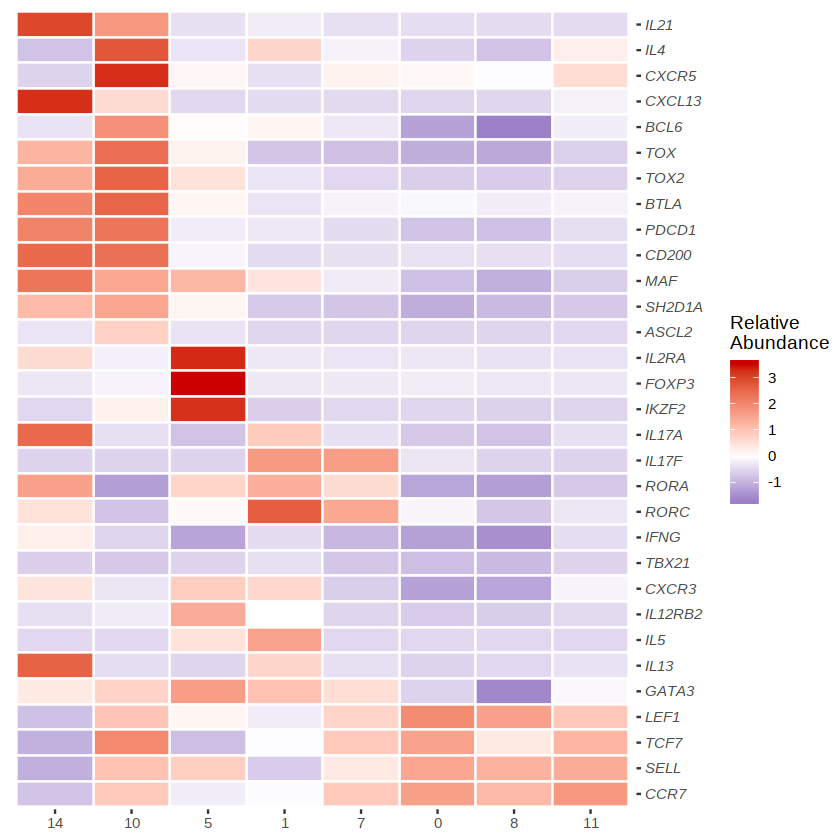

```r
p1 <- ggplot(df.ag, aes(x = Cluster, y=Gene, fill=RelAb)) +
  geom_tile(colour="white", size=.5) +
  scale_fill_gradient2(low = "blue4", high = "red3", mid = "white",# midpoint = 0, limit = c(-4,4),
                       space = "Lab", name="Relative\nAbundance") +
  scale_y_discrete(position = "right") +
  labs(x=NULL,y=NULL)+
  theme(axis.text.y.right = element_text(face="italic"),
        panel.background=element_blank())
# pdf('heatmap_kim_ll_cd4.pdf', height=4, width=4) ##(3): 4x4
p1
# dev.off()
```

```r
table(annot_ll$Cell_subtype, Idents(kp)) %>% write.csv(file="celltype_cluster_assignment.csv")
```

##### 5.1 Experiment with ScaleData, LogNormalize and relative abundance measures

The idea of relative abundance comes from https://www.nature.com/articles/nature24489 but depicted differently in Kim et al.

'CD200'

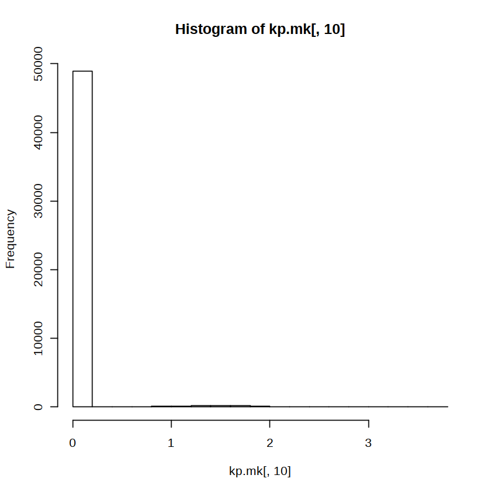

```r
#use CD200 as an example
names(kp.mk)[10]
hist(kp.mk[,10])
```

```r
load('kim_umi_ll.RData')

## repeat with previous steps
cd200.raw <- kp[['RNA']]['CD200',] %>% as.numeric
## then logNormalize
cd200.log <- kp[['RNA']]['CD200',] %>% as.numeric
## then scale
cd200.scl <- kp[['RNA']]['CD200',] %>% as.numeric

hist(kp@assays$RNA['CD200',] %>% as.numeric)
```

```r
kp <- ScaleData(kp, do.scale = F, do.center = T,assay='RNA', features=rownames(kp))
```

```
Centering data matrix
```

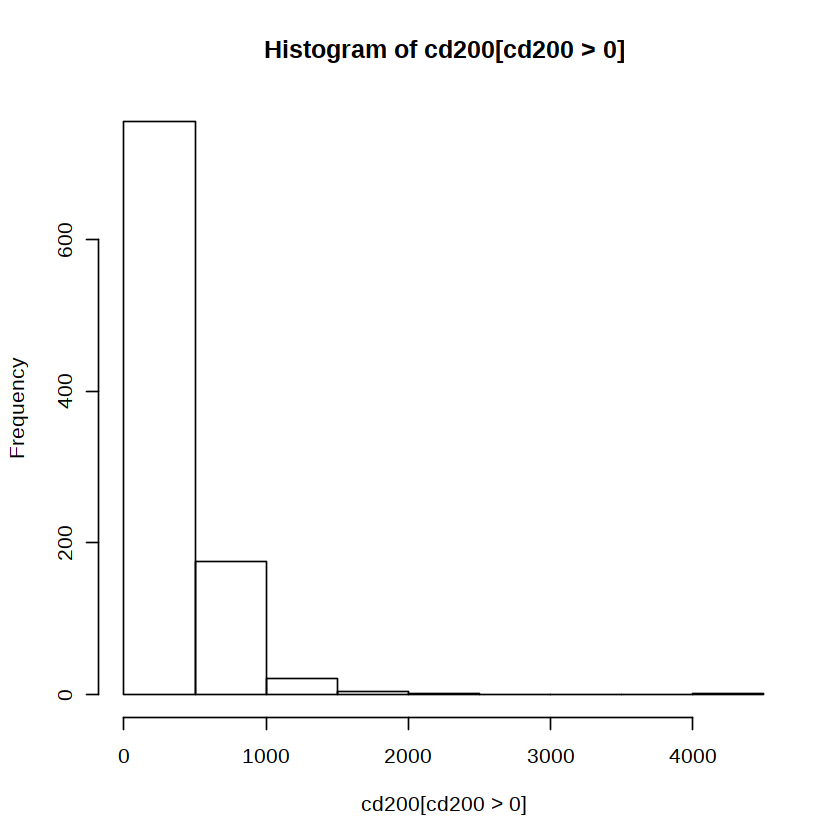

```r
cd200 <- kp[['RNA']]['CD200',] %>% as.numeric
hist(cd200[cd200>0])
```

Conclusion: ScaleData doesn't perform on `RNA` assay. Still not sure why `ScaleData` doesn't take effect on the data. But will continue munually with the procedures.

#### 6. Stack barplot of clusters

```r
origin <- table(annot_ll$Sample_Origin, Idents(kp)) %>% as.data.frame
names(origin) <- c("Origin","Cluster","Number")
origin <- origin[origin$Cluster %in% clusters.sel & origin$Origin %in% c("mLN",'nLN','tLung','nLung'),]
origin$Cluster <- factor(origin$Cluster, levels=clusters.sel)
origin$Origin <- factor(origin$Origin, levels=c("nLung",'tLung','nLN','mLN'))
```

http://sape.inf.usi.ch/quick-reference/ggplot2/colour

```r
for(c in levels(origin$Cluster)) origin$Number[origin$Cluster==c] <- origin$Number[origin$Cluster==c]/sum(origin$Number[origin$Cluster==c])*100
```

```r
p2 <- ggplot(origin, aes(x=Cluster, y=Number, fill=Origin)) +
    geom_bar(stat="identity", width=0.8) +
    scale_fill_manual(values=c("gold1","firebrick","darkseagreen2","green4")) +
    scale_y_continuous(position = "right") +
    labs(x=NULL, y="Percentage", size=.5)+
    theme(panel.background=element_blank())
```

```r
pdf('barplot_kim_ll_cd4_stack.pdf', width=6, height=2.5)
p2
dev.off()
```

**png:** 2

```r
library(grid)
library(gridExtra)
```

```r
p1 <- ggplot(df.ag, aes(x = Cluster, y=Gene, fill=RelAb)) +
  geom_tile(colour="white", size=.5) +
  scale_fill_gradient2(low = "blue4", high = "red3", mid = "white", midpoint = 0, limit = c(-2,4),
                       space = "Lab", name="Relative\nAbundance") +
  scale_y_discrete(position = "right") +
  labs(x=NULL,y=NULL)+
  theme(axis.text.y.right = element_text(face="italic"),
        panel.background=element_blank())
```

```r
pdf('heatmap_kim_ll_cd4_stack.pdf', width=6, height=12)
grid.arrange(p2, p1, nrow = 2, widths = 30, heights = c(10, 80))
dev.off()
```

**png:** 2

#### 7. Analysis of B cels

```r
library(ggplot2)
library(dplyr)
library(Seurat)
library(stringr)
library(data.table)
```

```r
rm(list=ls())
system('head -1 GSE131907_Lung_Cancer_raw_UMI_matrix.txt > header_count.txt')
umi_header <- readLines('header_count.txt')
samples <- strsplit(umi_header, split="\t")[[1]]
meta_umi <- data.frame(raw=samples[-1],
                       barcode = samples[-1] %>% strsplit(split="_") %>% sapply("[",1),
                       source = samples[-1] %>% strsplit(split="_") %>% sapply("[",2),
                       index = samples[-1] %>% strsplit(split="_") %>% sapply("[",3))

mat <- fread('GSE131907_Lung_Cancer_raw_UMI_matrix.txt')
dim(mat)

annot <- read.table('GSE131907_Lung_Cancer_cell_annotation.txt', sep="\t", header=T)
dim(annot)
head(annot)
sum(annot$Sample_Origin %in% c("mLN","nLN","nLung","tLung"))
annot$number <- annot$Index %>% as.character %>% strsplit(split="_") %>% sapply("[",3)
annot <- annot[match(meta_umi$raw, annot$Index),]
```

1. 29634

2. 208507

1. 208506

2. 7

| Index | Barcode | Sample | Sample_Origin | Cell_type | Cell_type.refined | Cell_subtype |
| --- | --- | --- | --- | --- | --- | --- |
| AAACCTGCAAGGTGTG_LUNG_N01 | AAACCTGCAAGGTGTG | LUNG_N01 | nLung | Myeloid cells | Myeloid cells | mo-Mac |
| AACTCCCGTTCACCTC_LUNG_N01 | AACTCCCGTTCACCTC | LUNG_N01 | nLung | Myeloid cells | Myeloid cells | mo-Mac |
| AACTCCCTCACGCGGT_LUNG_N01 | AACTCCCTCACGCGGT | LUNG_N01 | nLung | Myeloid cells | Myeloid cells | mo-Mac |
| AAGGAGCGTGTGCGTC_LUNG_N01 | AAGGAGCGTGTGCGTC | LUNG_N01 | nLung | Myeloid cells | Myeloid cells | mo-Mac |
| AAGGTTCAGGTACTCT_LUNG_N01 | AAGGTTCAGGTACTCT | LUNG_N01 | nLung | Myeloid cells | Myeloid cells | mo-Mac |
| ACACCAAAGTGTACGG_LUNG_N01 | ACACCAAAGTGTACGG | LUNG_N01 | nLung | Myeloid cells | Myeloid cells | mo-Mac |

147069

```r
sel0 <- intersect(which(annot$Sample_Origin %in% c("nLung","tLung","mLN","nLN")), which(annot$Cell_type.refined == "B lymphocytes"))
annot_ll <- annot[sel0,]
# sum(annot$Sample_Origin  %in% c("nLung","tLung","mLN","nLN") & annot$Cell_type.refined == "T/NK cells", na.rm=T)

class(mat) <- class(as.data.frame(mat))
mat_ll <- mat[,1+sel0]
# sum(names(mat_ll) == annot_ll$Index)

genes <- mat$Index
```

```r
annot_ll$index_new <- NA
for (num in levels(factor(annot_ll$number))){
    id <- which(annot_ll$number==num)
    annot_ll$index_new[id] <- paste0(num, "_", 1:length(id))
}

names(mat_ll) <- annot_ll$index_new
save(annot_ll, genes, mat_ll, file="kim_umi_llb.RData")
```

##### 7.1 Clustering of B cells

```r
rownames(mat_ll) <- genes
kp <- CreateSeuratObject(counts = mat_ll, project = "KimDataset", min.cells = 3, min.features = 200)
summary(kp)

kp[["percent.mt"]] <- PercentageFeatureSet(kp, pattern = "^MT-")
VlnPlot(kp, features = c("nFeature_RNA", "nCount_RNA", "percent.mt"), ncol = 3, pt.size=0)

plot1 <- FeatureScatter(kp, feature1 = "nCount_RNA", feature2 = "percent.mt")
plot2 <- FeatureScatter(kp, feature1 = "nCount_RNA", feature2 = "nFeature_RNA")
# CombinePlots(plots = list(plot1, plot2))
# kp <- subset(kp, subset = nCount_RNA < 15000 & nFeature_RNA < 5000 & percent.mt < 10)

## normalization
kp <- NormalizeData(kp, normalization.method = "LogNormalize", scale.factor = 10000)
# kp <- NormalizeData(kp, normalization.method = "RC", scale.factor = 1e6) ## for heatmap of relative expression
kp <- FindVariableFeatures(kp, selection.method = "vst", nfeatures = 2000)
top10 <- head(VariableFeatures(kp), 10)
plot1 <- VariableFeaturePlot(kp)
plot2 <- LabelPoints(plot = plot1, points = top10, repel = TRUE, xnudge = 0, ynudge = 0)
# CombinePlots(plots = list(plot1, plot2))

## dimension reduction
all.genes <- rownames(kp)
kp <- ScaleData(kp, features = all.genes)
kp <- RunPCA(kp, features = VariableFeatures(kp))
print(kp[["pca"]], dims = 1:5, nfeatures = 5)
VizDimLoadings(kp, dims = 1:5, reduction = "pca")
DimHeatmap(kp, dims = 1:6, cells = 500, balanced = TRUE)
DimPlot(kp, reduction="pca")
```

[output not shown]

```
Length  Class   Mode
     1 Seurat     S4
```

```r
## clustering cells
kp <- FindNeighbors(kp, dims = 1:20)
kp <- FindClusters(kp, resolution = 0.25)
# head(Idents(kp), 5)
table(Idents(kp))

# clusters50 <- Idents(kp)
clusters25 <- Idents(kp)
```

```
Modularity Optimizer version 1.3.0 by Ludo Waltman and Nees Jan van Eck

Number of nodes: 22592
Number of edges: 729420

Running Louvain algorithm...
Maximum modularity in 10 random starts: 0.9222
Number of communities: 9
Elapsed time: 3 seconds
```

```
   0    1    2    3    4    5    6    7    8
7272 5453 2707 2611 1849  943  908  569  280
```

```r
## UMPA
kp <- RunUMAP(kp, dims = 1:15)
DimPlot(kp, reduction = "umap")
# kp <- RunTSNE(kp, dims = 1:20)
# DimPlot(kp, reduction = "tsne")
```

```r
load('kim_umi_llb_seurat.RData')
```

```r
pdf('umap_kim_llb_25.pdf', width=7, height=6)
DimPlot(kp, reduction = "umap")
dev.off()
```

**png:** 2

```r
# save(kp, annot_ll, clusters25, clusters50, file="kim_umi_llb_seurat.RData")
# load('kim_umi_llb_seurat.RData')
```

```r
##calculate differential expression
kp.markers <- FindAllMarkers(kp, only.pos = TRUE, min.pct = 0.25, logfc.threshold = 0.25)
top30 <- kp.markers %>% group_by(cluster) %>% top_n(n = 30, wt = avg_logFC)
```

```r
write.csv(top30, file="top30_llb.csv")
```

```r
assignment <- table(annot_ll$Cell_subtype, Idents(kp))
write.csv(assignment, file="celltype_cluster_assignment_b.csv")
```

##### 7.2 Heatmap of B cell markers (2 resolutions 0.25/0.5)

```r
rm(list=ls())
# rownames(mat_ll) <- genes
# kp <- CreateSeuratObject(counts = mat_ll, project = "KimDataset", min.cells = 3, min.features = 200)
# kp <- NormalizeData(kp, normalization.method = "RC", scale.factor = 1e6) ## for heatmap of relative expression
# save(kp, clusters25, clusters50, annot_ll, file="kim_umi_llb_seurat_rc.RData")
load('kim_umi_llb_seurat_rc.RData')
```

```r
markers.b1 <- "AICDA, BCL6, POLH, P2RY8, SEMA4A, FOXO1, BACH2, BATF, CD86, IRF8, DOCK8" %>% strsplit(split=", ") %>% unlist
markers.b2 <- "PRDM1, SDC1, XBP1, MZB1, JCHAIN, IGHA1, IGHA2, IGHG1, IGHG2" %>% strsplit(split=", ") %>% unlist
markers.b3 <- "MS4A1, HLA-DRA" %>% strsplit(split=", ") %>% unlist
markers.b4 <- "CXCR5, PAX5" %>% strsplit(split=", ") %>% unlist #"GZMB, IRF4" %>% strsplit(split=", ") %>% unlist
```

```r
markers.sel <- c(markers.b1, markers.b2, markers.b3, markers.b4) %>% unique
Idents(kp) <- clusters25
```

```r
kp.mk <- kp[['RNA']][markers.sel,] %>% as.matrix %>% t()
kp.mk <- log(base=2, kp.mk+1) %>% as.data.frame
kp.mk$cluster <- Idents(kp)
kp.ag <- aggregate(kp.mk[,1:(ncol(kp.mk)-1)], list(kp.mk$cluster), mean)

# kp.ag <- apply(kp.ag[,-1], 1, function(x) scale(x, scale = F, center=T))
kp.ag <- scale(kp.ag[,-1])
rownames(kp.ag) <- levels(kp.mk$cluster)
clusters.sel <- c(5, 4, 6, 0, 1, 2, 3, 8, 7)
df.ag <- melt(kp.ag)
df.ag <- df.ag[df.ag$Var1 %in% clusters.sel,]
names(df.ag) <- c("Cluster","Gene","RelAb")
range(df.ag$RelAb)
df.ag$Gene <- factor(df.ag$Gene, levels=markers.sel %>% rev)
df.ag$Cluster <- factor(df.ag$Cluster, levels=clusters.sel)
```

1. -2.07021173423697

2. 2.66391080657691

```r
p1 <- ggplot(df.ag, aes(x = Cluster, y=Gene, fill=RelAb)) +
  geom_tile(colour="white", size=.5) +
  scale_fill_gradient2(low = "blue4", high = "red3", mid = "white", midpoint = 0, limit = c(-3,3),
                       space = "Lab", name="Relative\nAbundance") +
  scale_y_discrete(position = "right") +
  labs(x=NULL,y=NULL)+
  theme(axis.text.y.right = element_text(face="italic"),
        panel.background=element_blank())
pdf('heatmap_kim_llb_b25.pdf', height=4, width=5.1) ##(3): 4x4
p1
dev.off()
```

**png:** 2

##### 7.3 Stacked barplot for B cells

```r
clusters <- clusters25
clusters.sel <- clusters.sel
origin <- table(annot_ll$Sample_Origin, clusters) %>% as.data.frame
names(origin) <- c("Origin","Cluster","Number")
origin <- origin[origin$Cluster %in% clusters.sel & origin$Origin %in% c("mLN",'nLN','tLung','nLung'),]
origin$Cluster <- factor(origin$Cluster, levels=clusters.sel)
origin$Origin <- factor(origin$Origin, levels=c("nLung",'tLung','nLN','mLN'))
for(c in levels(origin$Cluster)) origin$Number[origin$Cluster==c] <- origin$Number[origin$Cluster==c]/sum(origin$Number[origin$Cluster==c])*100
```

```r
p2 <- ggplot(origin, aes(x=Cluster, y=Number, fill=Origin)) +
    geom_bar(stat="identity", width=0.8) +
    scale_fill_manual(values=c("gold1","firebrick","darkseagreen2","green4")) +
    scale_y_continuous(position = "right") +
    labs(x=NULL, y="Percentage", size=.5)+
    theme(panel.background=element_blank())
```

```r
pdf('barplot_kim_llb_b25_stack.pdf', width=6.5, height=2.5)
p2
dev.off()
```

**png:** 2

#### 8. Documentation

```r
library(Seurat)
?Seurat ## v3.1.0
rm(list=ls())
```

```r
# load('kim_umi_llb_seurat.RData')
load('kim_umi_ll_seurat.RData')
```

```r
rm(list=ls())
# load('kim_umi_ll_seurat.RData')
load('kim_umi_llb_seurat.RData')
```

```r
il17a <- kp[['RNA']]['IL17A', kp$seurat_clusters==14]
il13 <- kp[['RNA']]['IL13', kp$seurat_clusters==14]
```

```r
# plot(density(il17a %>% as.numeric))
# plot(density(il13 %>% as.numeric))
summary(il17a %>% as.numeric)
summary(il13 %>% as.numeric)
sum(il17a>0)
sum(il13>0)
sum(kp$seurat_clusters==14)
```

```
   Min. 1st Qu.  Median    Mean 3rd Qu.    Max.
0.00000 0.00000 0.00000 0.01589 0.00000 3.18421
```

```
   Min. 1st Qu.  Median    Mean 3rd Qu.    Max.
0.00000 0.00000 0.00000 0.02252 0.00000 2.67382
```

3

6

465

```r
ncell <- table(kp$seurat_clusters) %>% as.data.frame
names(ncell) <- c("cluster", "#cell")
write.csv(ncell, file="cluster_number_b.csv", row.names=F)
```